# 03-analyze_01-v01.R

aelhabr

Sun Dec 10 15:43:41 2017

# Analysis

With this knowledge in mind, let’s take begin with “basic” analysis, and work our way towards nddressing more specific questions.

## “Competition Level” Analysis

### Which *districts, regions, and conferences* have the most *distinct schools*? [^1]

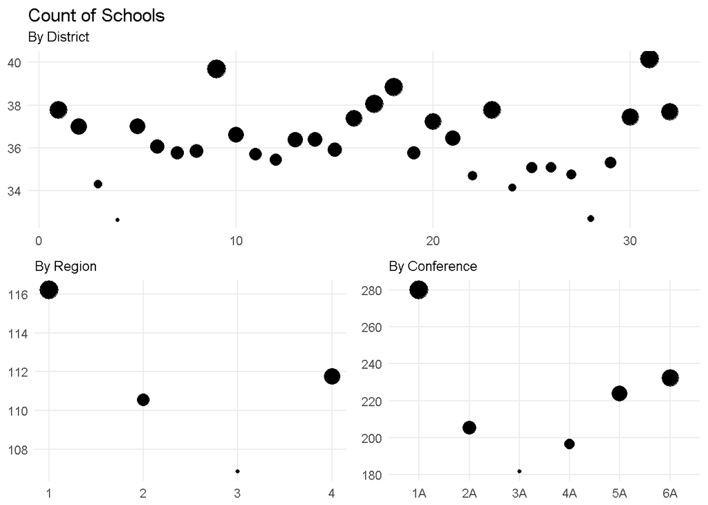

It seems fair to say that the distribution of schools among districts/regions/conferences is relatively even. This is to be expected since the UIL (presumably) tries to divide schools evenly among each grouping (to the extent possible) in order to stimulate fair competition.

### Which competition types have the most individual competitors and distinct schools?

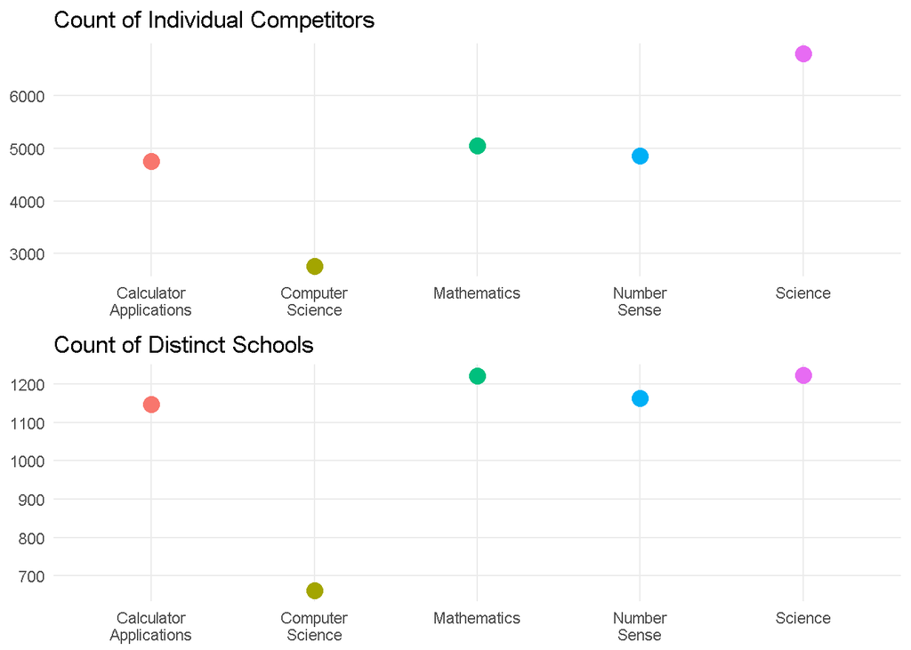

#### … at *each competition level*?

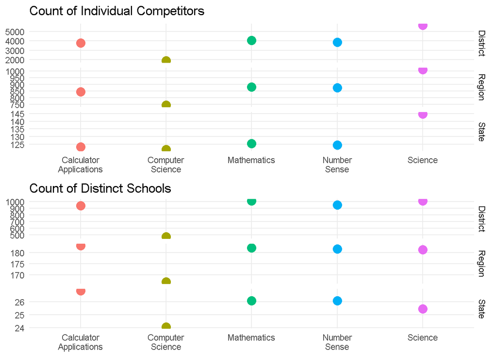

#### … in *each conference*?

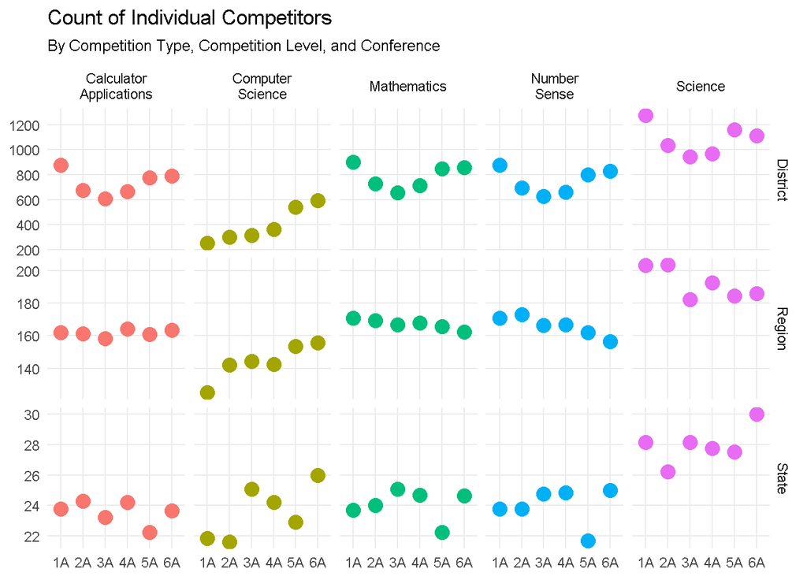

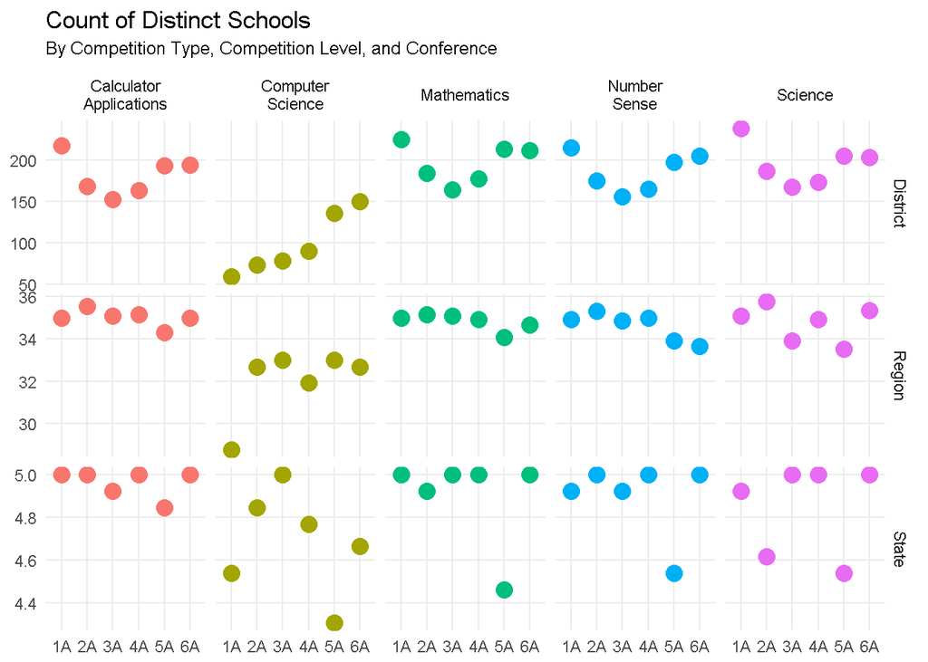

Just by inspection, science appears to be the answer to the numerous variations of the “Which competition type/level has the most …?” question.

### Which competition levels have the most distinct schools in *each conference*?

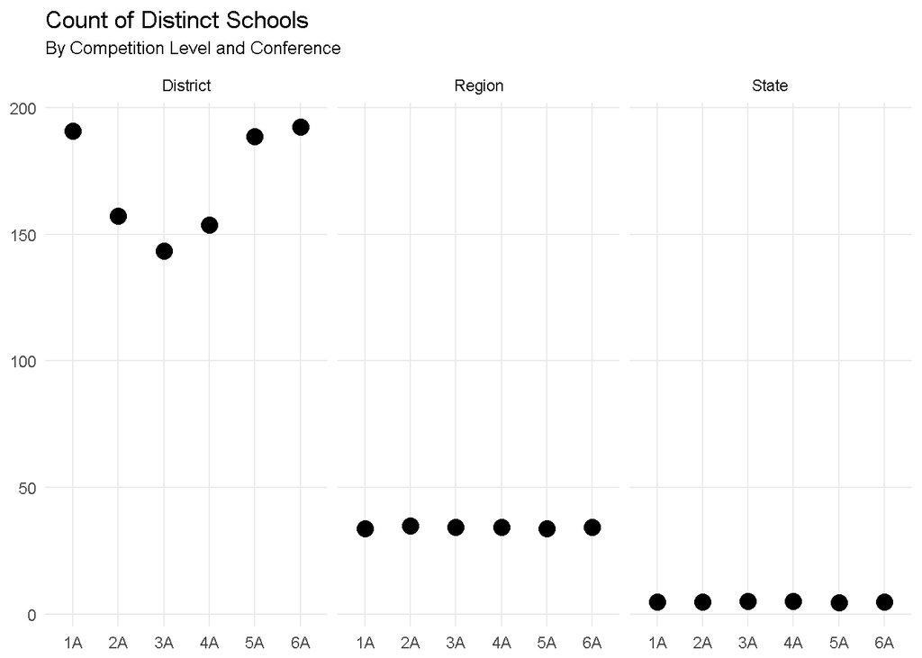

Note the difference in this “Which has the most …?” question–here, we are aggregating over different competition types, whereas previously we had distinguished between each).

[^1]: As a technical note, districts, regions, and conferences are not all of the same “type” in the data. Rather, `District` and `Region` are classified as disticnt factors in the `complvl` column (along with `State`) and conferences are classified in their own `conf` column. Nevertheless, for the purpose of exploration, these diferent “competition groupings” each stratify the sample population in some manner.